# Multiple regression lab

```r
library(dplyr)
library(PerformanceAnalytics)  # chart.Correlation
library(ellipse)  # plotcorr
library(car)  # vif
library(leaps)
library(MASS)  # stepAIC
```

# Linear model selection on crime data in USA

The dataset in `UScrime.dat` contains some demographic and social statistics for 47 american states in 1960. Among statistics, the criminality rate is given by # crimes reported per million inhabitants. Objective of the analysis is investigating the relationship between crime rate and socio-demographic features of states.

## Data exploration

1. Let’s upload the data and look at the first records:

```
      y young sud edu expp0 expp1 LFy male pop nonW unempl1 unempl2 assets poverty
1  79.1   151   1  91    58    56 510  950  33  301     108      41    394     261
2 163.5   143   0 113   103    95 583 1012  13  102      96      36    557     194
3  57.8   142   1  89    45    44 533  969  18  219      94      33    318     250
4 196.9   136   0 121   149   141 577  994 157   80     102      39    673     167
5 123.4   141   0 121   109   101 591  985  18   30      91      20    578     174
6  68.2   121   0 110   118   115 547  964  25   44      84      29    689     126
```

Crime rate ($y$) is the response variable, the covariates are:

- young : # males age 14-24 per $1000$
- sud : Southern or Northern state (1 = Yes, 0 = No)
- edu &: ($10\times$average) # of years adults (age $\geq25$) have been educated
- expp0 : 1960 per capita expenditure on police (by state and local government)
- expp1 : 1959 per capita expenditure on police (by state and local government)
- LFy : Labor force participation rate per 1000 civilian urban males age 14-24
- male : # males per $1000$ females
- pop : State population ($\times 100000$)
- nonW : # non-whites per $1000$
- unempl1 : Unemployment rate of urban males of age 14-24 per $1000$
- unempl2 : Unemployment rate of urban males of age 35-39 per $1000$
- assets : Median value of transferable goods and assets or family income ($\times 10$$)
- poverty : # families earning below $1/2$ the median income (of state)
2. Let’s have a summary of the variables. Check whether there is any categorical variable.

```
'data.frame':   47 obs. of  14 variables:
 $ y      : num  79.1 163.5 57.8 196.9 123.4 ...
 $ young  : int  151 143 142 136 141 121 127 131 157 140 ...
 $ sud    : int  1 0 1 0 0 0 1 1 1 0 ...
 $ edu    : int  91 113 89 121 121 110 111 109 90 118 ...
 $ expp0  : int  58 103 45 149 109 118 82 115 65 71 ...
 $ expp1  : int  56 95 44 141 101 115 79 109 62 68 ...
 $ LFy    : int  510 583 533 577 591 547 519 542 553 632 ...
 $ male   : int  950 1012 969 994 985 964 982 969 955 1029 ...
 $ pop    : int  33 13 18 157 18 25 4 50 39 7 ...
 $ nonW   : int  301 102 219 80 30 44 139 179 286 15 ...
 $ unempl1: int  108 96 94 102 91 84 97 79 81 100 ...
 $ unempl2: int  41 36 33 39 20 29 38 35 28 24 ...
 $ assets : int  394 557 318 673 578 689 620 472 421 526 ...
 $ poverty: int  261 194 250 167 174 126 168 206 239 174 ...
       y              young            sud              edu            expp0
 Min.   : 34.20   Min.   :119.0   Min.   :0.0000   Min.   : 87.0   Min.   : 45.0
 1st Qu.: 65.85   1st Qu.:130.0   1st Qu.:0.0000   1st Qu.: 97.5   1st Qu.: 62.5
 Median : 83.10   Median :136.0   Median :0.0000   Median :108.0   Median : 78.0
 Mean   : 90.51   Mean   :138.6   Mean   :0.3404   Mean   :105.6   Mean   : 85.0
 3rd Qu.:105.75   3rd Qu.:146.0   3rd Qu.:1.0000   3rd Qu.:114.5   3rd Qu.:104.5
 Max.   :199.30   Max.   :177.0   Max.   :1.0000   Max.   :122.0   Max.   :166.0
     expp1             LFy             male             pop              nonW
 Min.   : 41.00   Min.   :480.0   Min.   : 934.0   Min.   :  3.00   Min.   :  2.0
 1st Qu.: 58.50   1st Qu.:530.5   1st Qu.: 964.5   1st Qu.: 10.00   1st Qu.: 24.0
 Median : 73.00   Median :560.0   Median : 977.0   Median : 25.00   Median : 76.0
 Mean   : 80.23   Mean   :561.2   Mean   : 983.0   Mean   : 36.62   Mean   :101.1
 3rd Qu.: 97.00   3rd Qu.:593.0   3rd Qu.: 992.0   3rd Qu.: 41.50   3rd Qu.:132.5
 Max.   :157.00   Max.   :641.0   Max.   :1071.0   Max.   :168.00   Max.   :423.0
    unempl1          unempl2          assets         poverty
 Min.   : 70.00   Min.   :20.00   Min.   :288.0   Min.   :126.0
 1st Qu.: 80.50   1st Qu.:27.50   1st Qu.:459.5   1st Qu.:165.5
 Median : 92.00   Median :34.00   Median :537.0   Median :176.0
 Mean   : 95.47   Mean   :33.98   Mean   :525.4   Mean   :194.0
 3rd Qu.:104.00   3rd Qu.:38.50   3rd Qu.:591.5   3rd Qu.:227.5
 Max.   :142.00   Max.   :58.00   Max.   :689.0   Max.   :276.0
```

Just `sud` is a factor.

3. After excluded any categorical variable, let’s represent graphically the remaining variables one by one. (Try different graphical methods.)

E.g. `stripchart` (with possibly jitter)

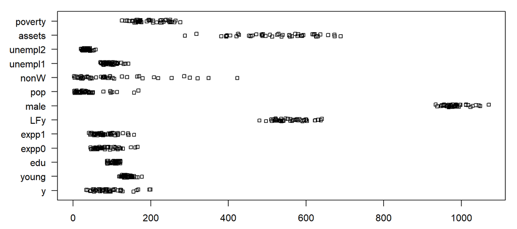

It might be more opportune to separate the charts by variables since they have different ranges.

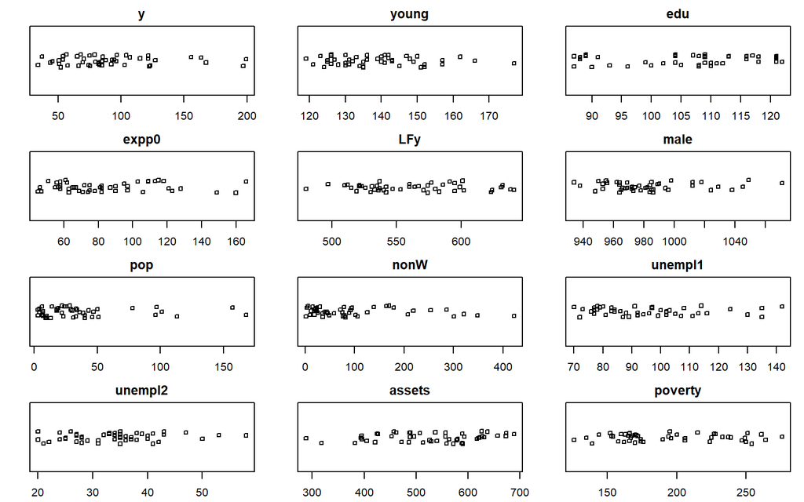

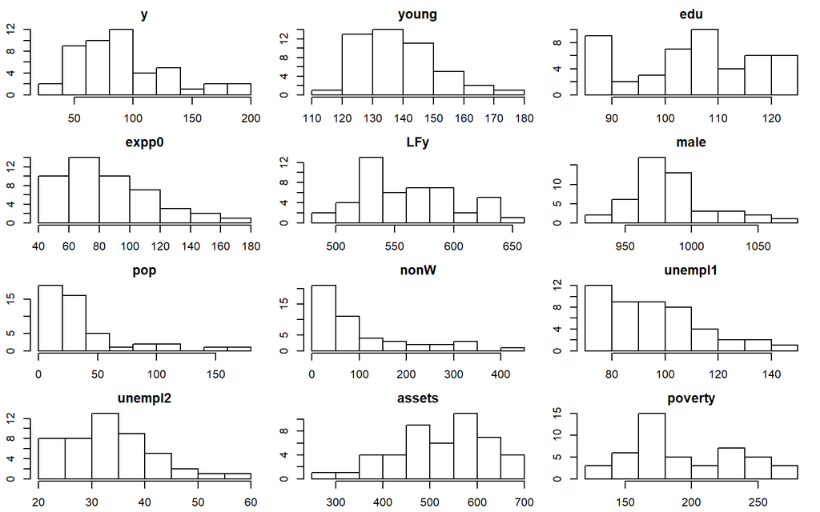

The response variable appear rather asymmetrical.

4. Let’s now look at the joint distribution of all variables. In particular, inspect any presence of **multicollinearity**.

```r
cor(USC)
```

```
            y young   sud   edu expp0 expp1   LFy  male   pop  nonW unempl1 unempl2 assets poverty
y        1.00 -0.09 -0.09  0.32  0.69  0.67  0.19  0.21  0.34  0.03   -0.05    0.18   0.44   -0.18
young   -0.09  1.00  0.58 -0.53 -0.51 -0.51 -0.16 -0.03 -0.28  0.59   -0.22   -0.24  -0.67    0.64
sud     -0.09  0.58  1.00 -0.70 -0.37 -0.38 -0.51 -0.31 -0.05  0.77   -0.17    0.07  -0.64    0.74
edu      0.32 -0.53 -0.70  1.00  0.48  0.50  0.56  0.44 -0.02 -0.66    0.02   -0.22   0.74   -0.77
expp0    0.69 -0.51 -0.37  0.48  1.00  0.99  0.12  0.03  0.53 -0.21   -0.04    0.19   0.79   -0.63
expp1    0.67 -0.51 -0.38  0.50  0.99  1.00  0.11  0.02  0.51 -0.22   -0.05    0.17   0.79   -0.65
LFy      0.19 -0.16 -0.51  0.56  0.12  0.11  1.00  0.51 -0.12 -0.34   -0.23   -0.42   0.29   -0.27
male     0.21 -0.03 -0.31  0.44  0.03  0.02  0.51  1.00 -0.41 -0.33    0.35   -0.02   0.18   -0.17
pop      0.34 -0.28 -0.05 -0.02  0.53  0.51 -0.12 -0.41  1.00  0.10   -0.04    0.27   0.31   -0.13
nonW     0.03  0.59  0.77 -0.66 -0.21 -0.22 -0.34 -0.33  0.10  1.00   -0.16    0.08  -0.59    0.68
unempl1 -0.05 -0.22 -0.17  0.02 -0.04 -0.05 -0.23  0.35 -0.04 -0.16    1.00    0.75   0.04   -0.06
unempl2  0.18 -0.24  0.07 -0.22  0.19  0.17 -0.42 -0.02  0.27  0.08    0.75    1.00   0.09    0.02
assets   0.44 -0.67 -0.64  0.74  0.79  0.79  0.29  0.18  0.31 -0.59    0.04    0.09   1.00   -0.88
poverty -0.18  0.64  0.74 -0.77 -0.63 -0.65 -0.27 -0.17 -0.13  0.68   -0.06    0.02  -0.88    1.00
```

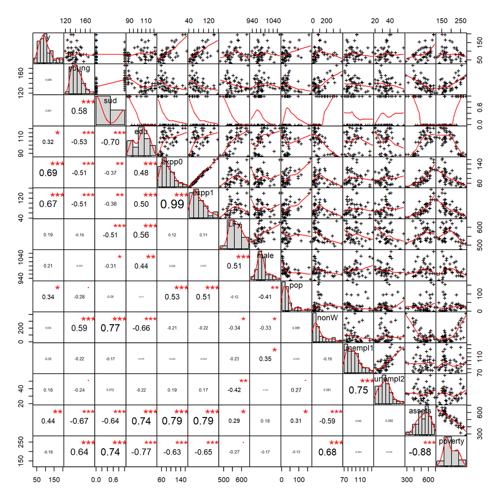

```r
chart.Correlation(USC)
```

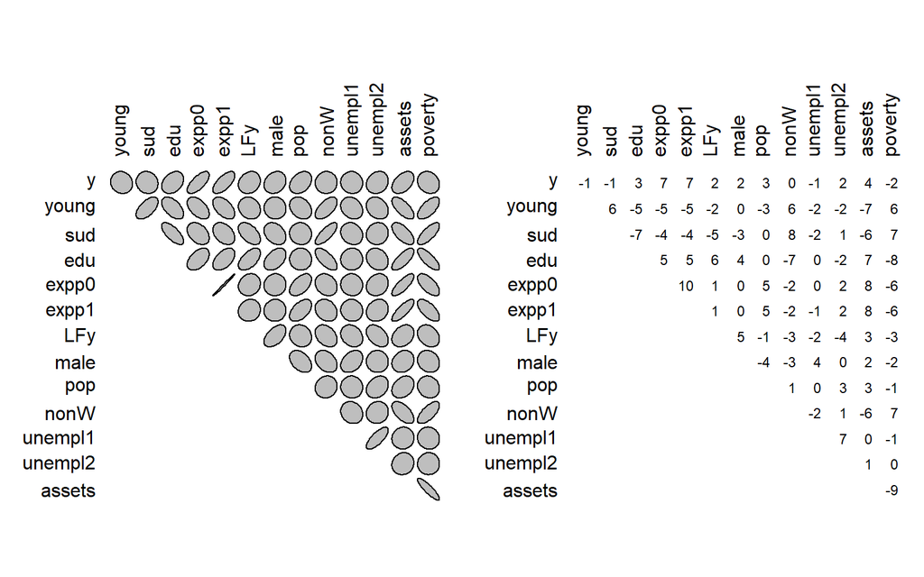

```r
plotcorr(cor(USC))
```

5. What are the most relevant covariates for $y$? What covariates are more troubling as far as collinearity is concerned?

## Multicollinearity

6. Let’s try different linear models which include either just `expp0` or just `expp1` or both. What do you note from the output below ?

```
Call:
lm(formula = y ~ expp0, data = USC)

Residuals:
    Min      1Q  Median      3Q     Max
-58.691 -15.563   3.252  13.958  56.884

Coefficients:
            Estimate Std. Error t value Pr(>|t|)
(Intercept)  14.4464    12.6693   1.140     0.26
expp0         0.8948     0.1409   6.353 9.34e-08 ***
---
Signif. codes:  0 '***' 0.001 '**' 0.01 '*' 0.05 '.' 0.1 ' ' 1

Residual standard error: 28.39 on 45 degrees of freedom
Multiple R-squared:  0.4728,    Adjusted R-squared:  0.4611
F-statistic: 40.36 on 1 and 45 DF,  p-value: 9.338e-08

Call:
lm(formula = y ~ expp1, data = USC)

Residuals:
    Min      1Q  Median      3Q     Max
-59.558 -15.676   1.229  14.674  59.374

Coefficients:
            Estimate Std. Error t value Pr(>|t|)
(Intercept)  16.5164    13.0427   1.266    0.212
expp1         0.9222     0.1537   6.001 3.11e-07 ***
---
Signif. codes:  0 '***' 0.001 '**' 0.01 '*' 0.05 '.' 0.1 ' ' 1

Residual standard error: 29.14 on 45 degrees of freedom
Multiple R-squared:  0.4445,    Adjusted R-squared:  0.4322
F-statistic: 36.01 on 1 and 45 DF,  p-value: 3.114e-07

Call:
lm(formula = y ~ expp0 + expp1, data = USC)

Residuals:
    Min      1Q  Median      3Q     Max
-63.609 -16.862   3.544  14.180  53.210

Coefficients:
            Estimate Std. Error t value Pr(>|t|)
(Intercept)   15.826     12.593   1.257   0.2155
expp0          2.562      1.234   2.076   0.0438 *
expp1         -1.783      1.312  -1.359   0.1810
---
Signif. codes:  0 '***' 0.001 '**' 0.01 '*' 0.05 '.' 0.1 ' ' 1

Residual standard error: 28.13 on 44 degrees of freedom
Multiple R-squared:  0.494, Adjusted R-squared:  0.471
F-statistic: 21.48 on 2 and 44 DF,  p-value: 3.094e-07
```

```
   expp0    expp1
78.21115 78.21115
```

7. The last output row shows an useful measure of multicollinearity. What is it? How can you calculate it?
8. Now let’s try the same experiment with the couple `(assets,poverty)`. What do you note?

VIF’s are:

```
  assets  poverty
4.575637 4.575637
```

Sometimes, it can be convenient to esclude some collinear covariates before starting with modelling.

9. Regardless, in the current study it is sensible to exclude both `expp0` and `expp1`. Why?

Let’s remove them from the dataset.

```r
USC_red <- USC[, -which(names(USC) == c("expp0", "expp1"))]
USC_red %>% head
      y young sud edu LFy male pop nonW unempl1 unempl2 assets poverty
1  79.1   151   1  91 510  950  33  301     108      41    394     261
2 163.5   143   0 113 583 1012  13  102      96      36    557     194
3  57.8   142   1  89 533  969  18  219      94      33    318     250
4 196.9   136   0 121 577  994 157   80     102      39    673     167
5 123.4   141   0 121 591  985  18   30      91      20    578     174
6  68.2   121   0 110 547  964  25   44      84      29    689     126
```

## Criteria for comparing models

The tools already seen for comparing models are the $R^2$ determinant coefficient and the analysis of variance (for the null hypothesis of a group of coefficients).

Let us recall the most known model selection criteria: $R^2_a$, $AIC$, $BIC$.

$$\bar R^2_a = 1-(1-R^{2})\frac{n-1}{n-p-1} = R^{2}-(1-R^{2})\frac{p}{n-p-1}.$$
$p$ is the total number of explanatory variables in the model (not including the constant term).\ Adjusted $R^2$ can also be written as
$$R^2_a = 1-\frac{RSS/n-p-1}{TSS/n-1}.$$

$$AIC = -2\log(L(\hat{\beta},\hat{\sigma}^2))+2(p+1)$$
that, for a linear regression model is
$$\text{AIC} = n\log \hat{\sigma}^2 + 2 (p+1)$$

$$BIC = -2\log(L(\hat{\beta},\hat{\sigma}^2)) + (p+1)\log n,$$
that, for a linear regression model is
$$BIC = n\log\hat{\sigma}^2 + (p+1)\log n,$$

### AIC and BIC in R

See `AIC()` and `BIC()` (they use function `logLik()` which gives the model ML.)\

`extractAIC()` uses a different normalization const.

## Variable Selection

Let’s select a model for USC dataset.

We start by estimating a model with all variables.

```
Call:
lm(formula = y ~ ., data = USC_red)

Residuals:
    Min      1Q  Median      3Q     Max
-50.115 -17.032  -2.742  14.177  53.631

Coefficients:
              Estimate Std. Error t value Pr(>|t|)
(Intercept) -900.80316  175.82194  -5.123  1.1e-05 ***
young          0.86532    0.50024   1.730  0.09248 .
sud          -19.02095   17.53434  -1.085  0.28543
edu            2.05480    0.75397   2.725  0.00996 **
LFy           -0.18624    0.17007  -1.095  0.28097
male           0.47342    0.23447   2.019  0.05119 .
pop            0.17917    0.14136   1.268  0.21333
nonW           0.10771    0.06806   1.583  0.12252
unempl1       -1.28273    0.48099  -2.667  0.01151 *
unempl2        2.77601    0.98484   2.819  0.00788 **
assets         0.31837    0.11480   2.773  0.00884 **
poverty        0.73896    0.27993   2.640  0.01231 *
---
Signif. codes:  0 '***' 0.001 '**' 0.01 '*' 0.05 '.' 0.1 ' ' 1

Residual standard error: 26.27 on 35 degrees of freedom
Multiple R-squared:  0.6491,    Adjusted R-squared:  0.5388
F-statistic: 5.885 on 11 and 35 DF,  p-value: 2.581e-05
```

Several covariates appear important.

10. Let’s check the model by some diagnostic tools. Do you see any misfitting?

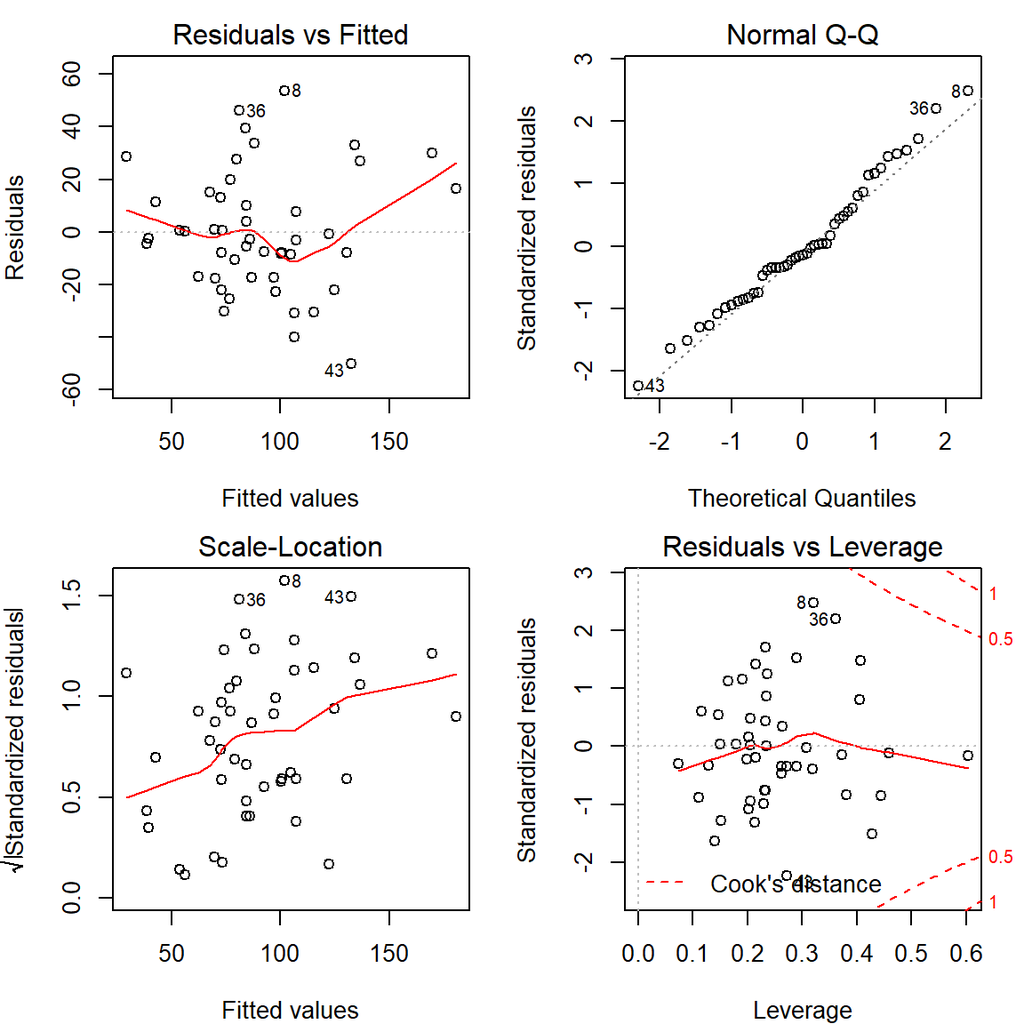

Given that sample size (47) is small as well as the number of regressors (11) is limited, we can estimate all the possible models.

11. How many are they?

$\ldots =$ 2048.